# Rendu Final – Les agriculteurs

Farhan, Ayoub, Enzo, Anis

14/01/2026

# Introduction :

Depuis l’arrivée de ChatGPT et autres outils similaires, l’intelligence artificielle s’est installée dans le quotidien de nombreux étudiants. Elle est souvent utilisée pour tenter de gagner du temps ou s’organiser, mais son utilité réelle fait débat.

Si l’IA modifie l’approche des étudiants face à leurs études en proposant de nouvelles solutions pour organiser le travail, réviser ou gérer le stress, ses effets réels restent à prouver. En effet, l’usage de ces outils soulève des questions quant à leur impact sur l’autonomie des étudiants et leur capacité à gérer leur temps de manière indépendante.

C’est pourquoi notre enquête cherche avant tout à interroger le vécu des étudiants du campus de Villetaneuse. Il s’agit de comprendre si ces derniers estiment que ces outils améliorent réellement leur organisation, ou s’ils perçoivent au contraire une modification de leur autonomie dans leur travail universitaire.

# Choix de la sous-problématique et des hypothèses

L’usage de l’IA par les étudiants soulève des questions majeures quant à son impact sur leur autonomie et leur gestion du temps. Si ces outils sont mobilisés pour automatiser certaines tâches et gagner du temps, il reste à déterminer si cette recherche de productivité favorise réellement leur indépendance ou si, au contraire, elle la fragilise.

C’est dans cette perspective que nous posons notre problématique :  
**Dans quelle mesure l’usage de l’IA pour gérer le stress, améliorer le bien-être et stimuler la créativité affecte-t-il l’autonomie des étudiants dans leur prise de décision et dans leur gestion des tâches académiques ?**

Dans le cadre de cette étude, plusieurs hypothèses ont été formulées pour explorer l’impact de l’usage de l’intelligence artificielle (IA) sur les étudiants, en particulier dans leurs études.

1. Les étudiants perçoivent l’IA principalement comme un outil pratique pour gagner du temps et améliorer la productivité.

2.Les étudiants utilisent l’IA au quotidien pour leur apporter un soutien psychologique, gérer leur stress et améliorer leur bien-être.

3.Les étudiants pensent que l’IA stimule la créativité en permettant d’imaginer, de concevoir et de tester rapidement leurs projets.

## **Diagramme de Venn**

[figure not shown]

# Variables d’intérêts et auxiliaires

| Axe d’analyse | Variables d’intérêts | Variables auxiliaires |
| --- | --- | --- |
| Productivité et gestion du temps | Q19 : Fréquence d’utilisation (variable clé) Q26 : Raison principale (gain de temps) Q22 : Temps passé avec l’IA | Q3 : Filière d’inscription |
| Bien-être et gestion du stress | Q37 : Sentiment de dépendance à l’IA Q33 : Usage de l’IA pour gérer le stress | Q2 : Année d’étude (niveau) |
| Création et réflexion | Q35 : Impact sur la réflexion (enrichit / réduit) Q28 : Usage pour résumés / fiches | Q3 : Filière d’inscription |

## Explication de la gestion de la qualité et choix des variables

#### **Identification du Plan de Sondage et des Hypothèses**

La sélection des variables d’intérêt a été guidée par un objectif de pertinence vis-à-vis des hypothèses choisis et structurées en axe pour une meilleur lisibilité. Par exemple, la variable **Q26** est mobilisée pour vérifier si l’IA est perçue comme un levier de productivité, tandis que la **Q33** interroge le lien ressenti entre l’usage de l’IA et la gestion du stress. La **Q35** permet de savoir l’impact de l’IA sur la réflexion lié à la filière d’inscription.  
Ces variables permettent de couvrir les divers axes de notre problématique.

L’estimation de la **qualité** de notre échantillon repose sur l’analyse des variables auxiliaires **Q3 (Filière)** et **Q2 (Niveau d’étude)**. Elles nous servent de base pour mesurer l’écart entre la structure de notre échantillon (qui a répondu) et la réalité du campus (la population cible).  
Pour s’assurer de la qualité de la distribution de ses variables auxiliaires nous avons contacter l’administration de Villetaneuse et avons fait des recherches pour avoir la distribution réelle de la population cible et ne pas biaisé nos estimations.

Pour nos analyses/estimations nous allons nous focaliser sur une ou deux variable d’intérêts par axe afin de répondre à notre problématique.

**La post-stratification**  
Notre échantillon étant désormais constitué, nous ne pouvons plus agir sur la méthode de sélection. Pour corriger les biais de représentativité identifiés (comme la sur-représentation des BAC+1-3), nous procéderons à une **post-stratification** (redressement). Cette technique consiste à réajuster le poids statistique des répondants pour que la structure finale de nos données se rapproche de la distribution réelle de la population étudiante, améliorant ainsi la précision de nos observations.

# Présentation descriptive de l’échantillon :

**Thème : L’usage de l’IA chez les étudiants du campus de Villetaneuse**

L’échantillon initial est composé de **1 050 répondants**, recueillis sur une période d’une semaine par les étudiants de BUT1 Sciences des Données. Lors de la collecte, des consignes précises ont été données afin de limiter les biais notamment le fait d’interroger tous le campus (pas uniquement l’IUT) et de veiller à une parité entre les hommes et les femmes.

Dans un premier temps, un travail de nettoyage et de filtrage a été réalisé sur la base de données nettoyés par nos soins. Nous avons exclu les répondants ne correspondant pas à la population cible, à savoir les étudiants du campus de Villetaneuse, ainsi que les questionnaires incomplets ou manifestement biaisés (réponses automatisées, réponses incohérentes).

Par ailleurs, certaines réponses ont nécessité un traitement supplémentaire, notamment concernant la variable liée à la filière d’études. En effet, plus de 100 répondants ont renseigné leur filière sous forme de texte libre, sans sélectionner les modalités prédéfinies du questionnaire. Afin de préserver la cohérence et l’exploitabilité des données, ces réponses ont été regroupées dans les filières les plus correspondantes, sur la base de leur contenu. Après application de ces critères, la taille de l’échantillon est ramenée à **938 répondants**.

Pour évaluer la représentativité de notre échantillon et comparer à la population cible *(étudiant du campus de Villetaneuse),* nous mobilisons deux types de sources d’information :

1. **Les données administratives internes :** Nous nous appuyonsprioritairement sur les statistiques officielles de l’Université pour connaître la répartition réelle par filière et par année demandé directement à l’administration.
2. **Les données comparatives externes (Internet) :** À défaut d’avoir des chiffres exacts nous consultons des enquêtes réalisées :  
   -https://www.univ-paris8.fr/Les-caracteristiques-du-public-etudiant  
   -https://www.devinci.fr/pdf/etude-impact-des-IA-generatives-sur-les-etudiants.pdf  
   -https://management-datascience.org/articles/31222/  
   -https://data.enseignementsup-recherche.gouv.fr/explore/dataset/fr-esr-sise-effectifs-d-etudiants-inscrits-esr-public/export/?refine.etablissement_lib=Universit%C3%A9+Sorbonne+Paris+Nord

**Voici les graphiques** présentant la répartition de notre échantillon en fonction des principales raisons de l’usage de l’IA, de la fréquence d’utilisation, de l’utilisation de l’IA pour gérer le stress et la performance, ainsi que de l’impact perçu de l’IA sur la réflexion académique des étudiants. Ces visualisations nous permettent d’évaluer la représentativité de l’échantillon et d’identifier les tendances générales au sein des répondants.

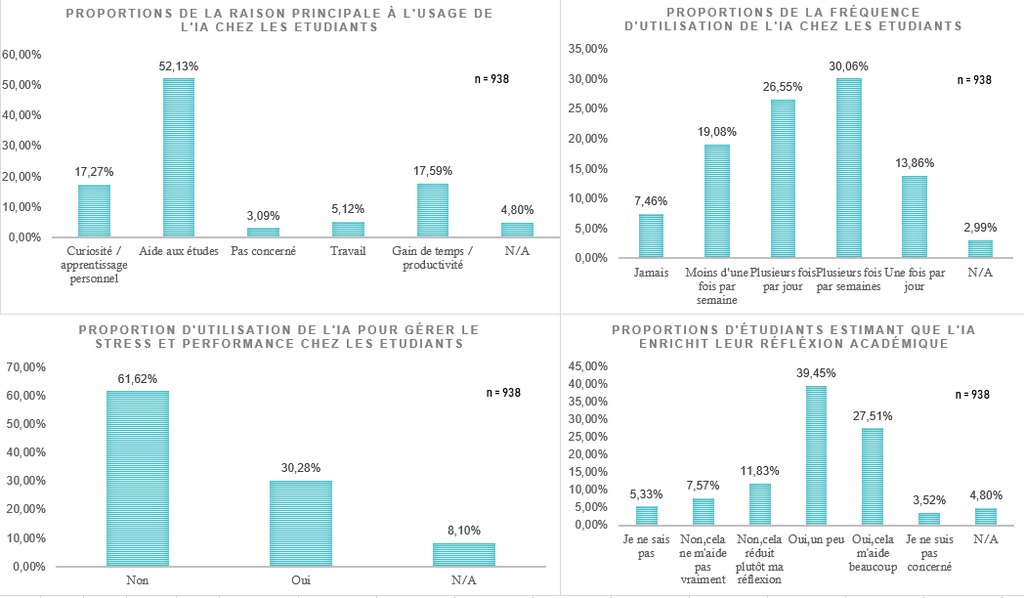

Les tendances montrent que l’IA est surtout utilisée pour améliorer l’organisation des études et gagner du temps, tandis que son utilisation pour gérer le stress est moins fréquente.  
Bien que de nombreux étudiants estiment que l’IA enrichit leur réflexion académique, certains restent sceptiques. Les réponses vides ont été conservées, car les exclure modifierait le nombre total de répondants (n), ce qui baisserait énormément son nombre et fausserait les résultats.

Cependant, ces tendances ne suffisent pas à elles seules.  
Nous allons utiliser des variables d’intérêt et auxiliaires pour vérifier la qualité des estimations, comparer les distributions dans l’échantillon et la population cible, et proposer des redressements si nécessaire. Nous nous assurerons que les variables auxiliaires sont pertinentes et basées sur des données fiables pour affiner nos conclusions.

# Comparaison de distribution variable auxiliaire

L’analyse suivante présente une comparaison graphique de la distribution d’une variable auxiliaire clé entre notre échantillon et la population cible, mettant en lumière les écarts de représentativité ou de sous représentativité :

Chaque image comporte deux graphiques : le premier compare la structure de notre échantillon à celle des étudiants de l’université Paris 8, et le second compare notre échantillon à la population totale de notre campus.

Cela vise à montrer qu’utiliser les proportions d’une autre université comme référence n’est pas pertinent même entre établissements proches géographiquement, il peut exister des différences de composition (sexe, âge, domaines de formation) qui biaisent l’interprétation.

Ensuite, pour simplifier l’analyse et pouvoir comparer avec les données de l’université Paris 8 et la population cible, on a **regroupé les niveaux d’étude** en trois grandes catégories. Les étudiants en **Licence** regroupent les niveaux BAC+1 à BAC+3, les étudiants en **Master** correspondent aux niveaux M1 et M2, et la dernière catégorie concerne les étudiants en **Doctorat**.

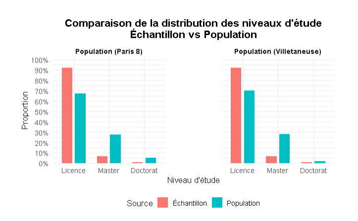

La comparaison des niveaux d’étude met en évidence un déséquilibre entre l’échantillon et la population cible. Dans la population cible, les étudiants de licence représentent 70,1%, ceux de master 27,9% et les doctorants 2%. Dans l’échantillon, la licence est fortement surreprésentée (92,2%), tandis que le master est nettement sous-représenté (6,85%) et le doctorat reste marginal (≈0,9%).

Ce décalage s’explique principalement par les modalités de diffusion du questionnaire, proposé surtout à des endroits et moments où les étudiants de Licence/BUT sont plus nombreux.  
Les étudiants de Master et de Doctorat, souvent moins présents sur le campus, ont donc été moins touchés. Il est aussi possible que le recueil fais par les BUT1 n’ait pas ciblé spécifiquement ces personnes.

Ainsi, les résultats reflètent surtout les pratiques et usages de l’IA des étudiants de Licence/BUT. Les comportements des étudiants de Master et de Doctorat étant sous-représentés, Montrer les résultats à l’ensemble du campus doit être faite avec prudence.  
*² : STS = Sciences, Technologies, Santé ; DEG = Droit, Économie, Gestion ; ALL = Arts, Lettres, Langues ; CC = Culture et communication ; SHS = Sciences humaines et sociales*

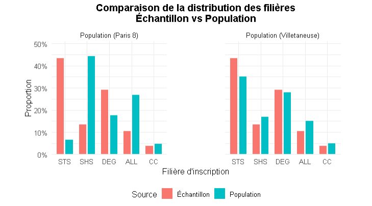

Sur la population cible (Villetaneuse), l’échantillon surreprésente **STS²** (≈44% vs ≈35%), représente assez bien **DEG** (≈29% vs ≈28%), et sous-représente **SHS** (≈14% vs ≈17%) ainsi que **ALL** (≈11% vs ≈15–16%). **CC** reste minoritaire et proche entre échantillon et population (≈4–5%), mais avec un poids faible.

Ce déséquilibre implique que les résultats décriront surtout les pratiques (dont l’usage de l’IA) des étudiants STS et aussi les DEG, tandis que les comportements des étudiants ALL/SHS risquent d’être moins bien captés.  
En conséquence, la généralisation des conclusions à l’ensemble du campus doit être faite avec prudence, notamment pour les analyses par filière. Néanmoins les proportions sont assez similaire entre l’échantillon et la population cible.

# Présentation des estimations et discussion sur la qualité

Le but de ce projet est de répondre à notre sous-problématique :  
*‘Dans quelle mesure l’usage de l’IA pour gérer le stress, améliorer le bien-être et stimuler la créativité affecte-t-il l’autonomie des étudiants dans leur prise de décision et dans leur gestion des tâches académiques ?’*

Dans un premier temps, nous avons calculé des résultats **sans redressement** avec le **plan simple** pour décrire les réponses à la question Q26 dans notre échantillon. Le plan simple est utilisé ici comme point de départ, car il permet de calculer facilement les proportions et une première mesure d’incertitude (variance et intervalle de confiance) avec des formules classiques.

Cette étape permet de voir rapidement quelles réponses reviennent le plus souvent, mais les résultats peuvent être un peu faussés si certaines filières sont trop représentées ou pas assez représentées dans l’échantillon par rapport à la population cible. C’est pour cela que nous faisons ensuite un redressement en utilisant la filière

Pour montrer si nos résultats sont fiables, on ajoute un **intervalle de confiance à 95%**. Il sert à donner une “marge d’erreur” autour de la proportion estimée : autrement dit, il indique une zone où la vraie proportion dans la population a de fortes chances de se trouver, parce qu’on ne questionne qu’une partie des étudiants.

Pour calculer cet intervalle, on a d’abord besoin de mesurer l’incertitude de l’estimation. On calcule donc la variance (puis l’erreur‑type) en utilisant l’hypothèse d’un **plan simple** avant redressement. Comme on ne connaît pas la vraie variance de la population, on l’estime à partir de l’échantillon (variance “corrigée”).

Voici les formules que nous avons utilisés: p désigne la proportion par modalité

$$\widehat{\mathrm{Var}}(\hat p)=\left(1-\frac{n}{N}\right)\frac{\hat
p(1-\hat p)}{n-1}.$$

$$IC_{95\%}(\hat p)=\left[\hat p-1.96\,\widehat{SE}(\hat p)\;;\;\hat
p+1.96\,\widehat{SE}(\hat p)\right].$$
Voici le tableau montrant les différentes estimations pour cette axe en plan simple

```r
# ============================================================
# Q26 (UTILEIA 26) — NETTOYAGE + ESTIMATION AVANT REDRESSEMENT
# (plan simple SRS sans remise + FPC + IC95)
#AIDE PAR l'IA POUR LE CODE
# ============================================================

library(readxl)
library(dplyr)
library(stringr)

# -----------------------------
# 0) Paramètre population
# -----------------------------
N <- 14000  # taille population (campus Villetaneuse)

# -----------------------------
# 1) Import
# -----------------------------
donnees_brutes <- read_excel("C:/Users/Enzo/Downloads/Classeur1 (1).xlsx")
# -----------------------------
# 2) Repérer les colonnes utiles
# -----------------------------
colonne_villetaneuse <- names(donnees_brutes)[
  str_detect(str_to_lower(names(donnees_brutes)), "etuvil|villetaneuse")
][1]

colonne_filiere <- names(donnees_brutes)[
  str_detect(str_to_lower(names(donnees_brutes)), "3\\.?\\s*filiere|filiere")
][1]

colonne_q26 <- names(donnees_brutes)[
  str_detect(str_to_lower(names(donnees_brutes)), "\\b26\\b|utileia\\s*26|q26")
][1]

# -----------------------------
# 3) Nettoyage Q26 + filière_5 + filtre Villetaneuse
# -----------------------------
df_q26 <- donnees_brutes %>%
  mutate(
    # Villetaneuse
    indicateur_villetaneuse = str_to_lower(str_squish(as.character(.data[[colonne_villetaneuse]]))),

    # Filière brute
    filiere_texte = str_to_lower(str_squish(as.character(.data[[colonne_filiere]]))),

    # Q26 : texte + NA -> "N/A"
    Q26 = str_squish(as.character(.data[[colonne_q26]])),
    Q26 = ifelse(is.na(Q26) | Q26 == "", "N/A", Q26),

    # Filière en 5 catégories
    filiere_5 = case_when(
      filiere_texte %in% c("st", "sts") | str_detect(filiere_texte, "techn|sant") ~ "STS",
      filiere_texte %in% c("sh", "shs") | str_detect(filiere_texte, "humaine|social") ~ "SHS",
      filiere_texte %in% c("de", "deg") | str_detect(filiere_texte, "droit|économie|economie|gestion") ~ "DEG",
      filiere_texte %in% c("cc")        | str_detect(filiere_texte, "culture|communic") ~ "CC",
      filiere_texte %in% c("al", "all") | str_detect(filiere_texte, "arts|lettres|lang") ~ "ALL",
      TRUE ~ NA_character_
    )
  ) %>%
  filter(indicateur_villetaneuse %in% c("1", "oui", "true")) %>%
  filter(!is.na(filiere_5)) %>%
  select(filiere_5, Q26)

# -----------------------------
# 4) Estimation AVANT redressement (plan simple)
# -----------------------------
est_plan_simple_q26 <- df_q26 %>%
  count(Q26, name = "n_modalite") %>%  # count() de dplyr [web:647]
  mutate(
    n_total = sum(n_modalite),
    p_hat   = n_modalite / n_total,

    # Variance SRS sans remise + FPC
    var_srs_fpc = (1 - n_total / N) * p_hat * (1 - p_hat) / (n_total - 1),
    se_srs_fpc  = sqrt(var_srs_fpc),

    # IC 95%
    IC95_inf = pmax(0, p_hat - 1.96 * se_srs_fpc),
    IC95_sup = pmin(1, p_hat + 1.96 * se_srs_fpc)
  ) %>%
  select(Q26, n_modalite, p_hat, var_srs_fpc, IC95_inf, IC95_sup) %>%
  arrange(desc(p_hat))

est_plan_simple_q26
```

| Q26 | n_modalite | p_hat | var_srs_fpc | IC95_inf | IC95_sup |
| --- | --- | --- | --- | --- | --- |
| ETU | 477 | 0.52302632 | 2.560029e-04 | 0.49166614 | 0.55438649 |
| TEM | 162 | 0.17763158 | 1.499041e-04 | 0.15363426 | 0.20162890 |
| CUR | 158 | 0.17324561 | 1.469825e-04 | 0.14948329 | 0.19700794 |
| PRO | 48 | 0.05263158 | 5.116726e-05 | 0.03861145 | 0.06665171 |
| N/A | 38 | 0.04166667 | 4.097625e-05 | 0.02912018 | 0.05421315 |
| PC | 29 | 0.03179825 | 3.159337e-05 | 0.02078148 | 0.04281501 |

²=PC : Pas concerné TEM : Gain de temps / productivité CUR : Curiosité / apprentissage personnel ETU : Aide aux études (rédaction, révision, synthèse, vérification d’informations) PRO:Travail,aprentissage

En plan simple, la part des étudiants déclarant un usage de l’IA motivé par un gain de temps et une recherche de productivité (modalité TEM) est estimée à environ 17,8 %.  
L’intervalle de confiance à 95 % compris entre 15,4 % et 20,2 % indique que l’estimation est précise. Ce résultat montre qu’une part non négligeable des étudiants utilise l’IA principalement pour optimiser ponctuellement leur travail universitaire.

Passons maintenant au plan stratifié avec le redressement : Pour les redressements on a utilisés ses formules: Avec $f_h=\dfrac{n_h}{N_h}$ :

$$\widehat{\mathrm{Var}}(\hat p_{st})
=\sum_{h=1}^{H} W_h^{2}\left(1-f_h\right)\frac{\hat p_h(1-\hat
p_h)}{n_h-1}$$

Puis :
$$\widehat{SE}(\hat p_{st})=\sqrt{\widehat{\mathrm{Var}}(\hat p_{st})}
\quad\text{et}\quad
IC_{95\%}(\hat p_{st})=\left[\hat p_{st}-1.96\,\widehat{SE}\;;\;\hat
p_{st}+1.96\,\widehat{SE}\right].$$

```r
library(readxl)
library(dplyr)
library(stringr)
library(tidyr)
library(tibble)

# -----------------------------
# 0) Paramètres population
# -----------------------------
taille_population <- 14000  # N

population_cible <- tibble(
  filiere_5 = c("STS","SHS","DEG","CC","ALL"),
  W_h = c(0.35, 0.17, 0.28, 0.05, 0.15)
) %>%
  mutate(N_h = round(taille_population * W_h))  # tailles de strates redressé

# -----------------------------
# 1) Import des données
# -----------------------------
donnees_brutes <- read_excel("C:/Users/Enzo/Downloads/Classeur1 (1).xlsx")
# ---------------------------------------------------------
# 2) Trouver les colonnes utiles (selon les noms du fichier)
# ---------------------------------------------------------
colonne_villetaneuse <- names(donnees_brutes)[
  str_detect(str_to_lower(names(donnees_brutes)), "etuvil|villetaneuse")
][1]

colonne_filiere <- names(donnees_brutes)[
  str_detect(str_to_lower(names(donnees_brutes)), "3\\.?\\s*filiere|filiere")
][1]

colonne_q26 <- names(donnees_brutes)[
  str_detect(str_to_lower(names(donnees_brutes)), "\\b26\\b|q26")
][1]

# ---------------------------------------------------------
# 3) Nettoyage / recodage des variables
# ---------------------------------------------------------
donnees_nettoyees <- donnees_brutes %>%
  mutate(
    # Villetaneuse : standardiser en texte
    indicateur_villetaneuse = str_to_lower(str_squish(as.character(.data[[colonne_villetaneuse]]))),

    # Filère : texte brut standardisé
    filiere_texte = str_to_lower(str_squish(as.character(.data[[colonne_filiere]]))),

    # Q26 : texte + NA -> "N/A"
    q26 = str_squish(as.character(.data[[colonne_q26]])),
    q26 = ifelse(is.na(q26) | q26 == "", "N/A", q26),

    # Recodage filière en 5 catégories
    filiere_5 = case_when(
      filiere_texte %in% c("st","sts") | str_detect(filiere_texte, "techn|sant") ~ "STS",
      filiere_texte %in% c("sh","shs") | str_detect(filiere_texte, "humaine|social") ~ "SHS",
      filiere_texte %in% c("de","deg") | str_detect(filiere_texte, "droit|économie|economie|gestion") ~ "DEG",
      filiere_texte %in% c("cc")       | str_detect(filiere_texte, "culture|communic") ~ "CC",
      filiere_texte %in% c("al","all") | str_detect(filiere_texte, "arts|lettres|lang") ~ "ALL",
      TRUE ~ NA_character_
    )
  ) %>%
  # Filtrer Villetaneuse
  filter(indicateur_villetaneuse %in% c("1","oui","true")) %>%
  # Garder seulement les filières reconnues
  filter(!is.na(filiere_5)) %>%
  # Optionnel : enlever les lignes sans réponse Q26 (si  exclure "N/A", décommente)
  # filter(q26 != "N/A")
  select(filiere_5, q26)

# ---------------------------------------------------------
# 4) Passage en indicatrices y (0/1) pour chaque modalité Q26
# ---------------------------------------------------------
donnees_long <- donnees_nettoyees %>%
  mutate(id = row_number()) %>%
  mutate(valeur = 1L) %>%
  pivot_wider(names_from = q26, values_from = valeur, values_fill = 0L) %>%  # valeurs manquantes -> 0 [web:424]
  pivot_longer(
    cols = -c(id, filiere_5),
    names_to = "modalite_q26",
    values_to = "y"
  )

# ---------------------------------------------------------
# 5) Stats par strate h (filière) : n_h, p_h, f_h
# ---------------------------------------------------------
stats_strates <- donnees_long %>%
  left_join(population_cible, by = "filiere_5") %>%
  group_by(modalite_q26, filiere_5) %>%
  summarise(
    W_h = first(W_h),
    N_h = first(N_h),
    n_h = n(),
    p_h = mean(y),
    f_h = n_h / N_h,
    .groups = "drop"
  )

# ---------------------------------------------------------
# 6) Estimation stratifiée + variance stratifiée + IC95
#
# ---------------------------------------------------------
resultats_q26_stratif <- stats_strates %>%
  group_by(modalite_q26) %>%
  summarise(
    p_stratif = sum(W_h * p_h),
    var_stratif = sum(W_h^2 * (1 - f_h) * (p_h * (1 - p_h)) / pmax(n_h - 1, 1)),
    ic95_inf = pmax(0, p_stratif - 1.96 * sqrt(var_stratif)),
    ic95_sup = pmin(1, p_stratif + 1.96 * sqrt(var_stratif)),
    .groups = "drop"
  ) %>%
  arrange(desc(p_stratif))

resultats_q26_stratif
```

| modalite_q26 | p_stratif | var_stratif | ic95_inf | ic95_sup |
| --- | --- | --- | --- | --- |
| ETU | 0.51768003 | 2.676565e-04 | 0.48561401 | 0.54974604 |
| TEM | 0.18210558 | 1.632661e-04 | 0.15706156 | 0.20714960 |
| CUR | 0.17047590 | 1.509070e-04 | 0.14639844 | 0.19455337 |
| PRO | 0.05327178 | 5.571440e-05 | 0.03864193 | 0.06790162 |
| N/A | 0.04020049 | 3.877247e-05 | 0.02799605 | 0.05240493 |
| PC | 0.03626623 | 4.290069e-05 | 0.02342850 | 0.04910396 |

²

Après stratification par la filière, la proportion associée à la modalité TEM est estimée à environ 18,2 %, avec un intervalle de confiance à 95 % compris entre 15,7 % et 20,7 %.  
La proximité des intervalles de confiance entre les deux plans montre que le résultat est stable et peu sensible à la structure de l’échantillon ou alors les variables ne seraient pas liés entre elles.  
Le redressement confirme ainsi que l’usage de l’IA dans une logique de gain de temps et de productivité concerne une part comparable d’étudiants à l’échelle du campus.

Au regard de la problématique générale, cet usage orienté vers l’optimisation du travail montre que l’IA est mobilisée comme un outil de soutien plutôt que comme un substitut au raisonnement personnel.  
Les étudiants semblent conserver leur autonomie tout en utilisant l’IA pour améliorer leur efficacité, ce qui va dans le sens de l’hypothèse selon laquelle l’IA est principalement utilisée comme un outil de gain de temps et de productivité.

**Analysons maintenant l’axe sur la création et la réflexion**

```r
library(dplyr)

N <- 14000  # taille population

est_plan_simple_q35 <- donnees_brutes %>%
  mutate(
    reflexia35 = suppressWarnings(as.integer(`35. REFLEXIA`))
  ) %>%
  filter(!is.na(reflexia35)) %>%
  count(reflexia35, name = "n_modalite") %>%
  mutate(
    n_total = sum(n_modalite),
    p_hat   = n_modalite / n_total,

    # Variance SRS sans remise + correction population finie (FPC)
    var_srs_fpc = (1 - n_total / N) * p_hat * (1 - p_hat) / (n_total - 1),
    se_srs_fpc  = sqrt(var_srs_fpc),

    # IC 95%
    IC95_inf = pmax(0, p_hat - 1.96 * se_srs_fpc),
    IC95_sup = pmin(1, p_hat + 1.96 * se_srs_fpc)
  ) %>%
  mutate(
    modalite = case_when(
      reflexia35 == 1 ~ "Je ne sais pas",
      reflexia35 == 2 ~ "Non, cela ne m'aide pas vraiment",
      reflexia35 == 3 ~ "Non, cela réduit plutôt ma réflexion",
      reflexia35 == 4 ~ "Oui, un peu",
      reflexia35 == 5 ~ "Oui, cela m'aide beaucoup",
      reflexia35 == 6 ~ "Je ne suis pas concerné",
      TRUE ~ "Autre"
    )
  ) %>%
  select(reflexia35, modalite, n_modalite, p_hat, var_srs_fpc, IC95_inf, IC95_sup) %>%
  arrange(desc(p_hat))

est_plan_simple_q35
```

| reflexia35 | modalite | n_modalite | p_hat | var_srs_fpc | IC95_inf | IC95_sup |
| --- | --- | --- | --- | --- | --- | --- |
| 4 | Oui, un peu | 410 | 0.41082164 | 2.254691e-04 | 0.38139101 | 0.44025228 |
| 5 | Oui, cela m'aide beaucoup | 290 | 0.29058116 | 1.920247e-04 | 0.26342086 | 0.31774147 |
| 3 | Non, cela réduit plutôt ma réflexion | 126 | 0.12625251 | 1.027574e-04 | 0.10638412 | 0.14612089 |
| 2 | Non, cela ne m'aide pas vraiment | 84 | 0.08416834 | 7.180445e-05 | 0.06755979 | 0.10077689 |
| 1 | Je ne sais pas | 52 | 0.05210421 | 4.600662e-05 | 0.03880988 | 0.06539853 |
| 6 | Je ne suis pas concerné | 36 | 0.03607214 | 3.238944e-05 | 0.02491745 | 0.04722684 |

```r
library(readxl)
library(dplyr)
library(stringr)
library(tidyr)
library(tibble)

# -----------------------------
# 0) Paramètres population
# -----------------------------
taille_population <- 14000  # N

population_cible <- tibble(
  filiere_5 = c("STS","SHS","DEG","CC","ALL"),
  W_h = c(0.35, 0.17, 0.28, 0.05, 0.15)
) %>%
  mutate(N_h = round(taille_population * W_h))  # tailles de strates (redressé)



# ---------------------------------------------------------
# 2) Trouver les colonnes utiles (selon les noms du fichier)
# ---------------------------------------------------------
colonne_villetaneuse <- names(donnees_brutes)[
  str_detect(str_to_lower(names(donnees_brutes)), "etuvil|villetaneuse")
][1]

colonne_filiere <- names(donnees_brutes)[
  str_detect(str_to_lower(names(donnees_brutes)), "3\\.?\\s*filiere|filiere")
][1]

colonne_q35 <- names(donnees_brutes)[
  str_detect(str_to_lower(names(donnees_brutes)), "\\b35\\b|reflexia")
][1]

# ---------------------------------------------------------
# 3) Nettoyage / recodage des variables
# ---------------------------------------------------------
donnees_nettoyees <- donnees_brutes %>%
  mutate(
    indicateur_villetaneuse = str_to_lower(str_squish(as.character(.data[[colonne_villetaneuse]]))),
    filiere_texte = str_to_lower(str_squish(as.character(.data[[colonne_filiere]]))),

    # Q35 en 1..6
    reflexia35 = suppressWarnings(as.integer(.data[[colonne_q35]])),
    reflexia35 = ifelse(reflexia35 %in% 1:6, reflexia35, NA_integer_),

    filiere_5 = case_when(
      filiere_texte %in% c("st","sts") | str_detect(filiere_texte, "techn|sant") ~ "STS",
      filiere_texte %in% c("sh","shs") | str_detect(filiere_texte, "humaine|social") ~ "SHS",
      filiere_texte %in% c("de","deg") | str_detect(filiere_texte, "droit|économie|economie|gestion") ~ "DEG",
      filiere_texte %in% c("cc")       | str_detect(filiere_texte, "culture|communic") ~ "CC",
      filiere_texte %in% c("al","all") | str_detect(filiere_texte, "arts|lettres|lang") ~ "ALL",
      TRUE ~ NA_character_
    ),

    # Libellés Q35 (utilisés pour faire des colonnes propres)
    reflexia35_lbl = factor(
      reflexia35,
      levels = 1:6,
      ordered = TRUE,
      labels = c(
        "Je ne sais pas",
        "Non, cela ne m'aide pas vraiment",
        "Non, cela réduit plutôt ma réflexion",
        "Oui, un peu",
        "Oui, cela m'aide beaucoup",
        "Je ne suis pas concerné"
      )
    )
  ) %>%
  filter(indicateur_villetaneuse %in% c("1","oui","true")) %>%
  filter(!is.na(filiere_5)) %>%
  filter(!is.na(reflexia35_lbl)) %>%
  select(filiere_5, reflexia35_lbl)

# ---------------------------------------------------------
# 4) Indicatices 0/1 par modalité de Q35 (version corrigée)
#    Important : on ne garde QUE les colonnes utiles avant pivot
# ---------------------------------------------------------
donnees_long <- donnees_nettoyees %>%
  transmute(
    id = row_number(),
    filiere_5,
    reflexia35_lbl
  ) %>%
  mutate(valeur = 1L) %>%
  pivot_wider(
    names_from  = reflexia35_lbl,
    values_from = valeur,
    values_fill = 0L
  ) %>%  # valeurs manquantes -> 0 [web:424]
  pivot_longer(
    cols = -c(id, filiere_5),
    names_to = "modalite_q35",
    values_to = "y"
  )  # pivot_longer "lengthens" wide->long [web:451]

# ---------------------------------------------------------
# 5) Stats par strate h (filière) : n_h, p_h, f_h
# ---------------------------------------------------------
stats_strates <- donnees_long %>%
  left_join(population_cible, by = "filiere_5") %>%
  group_by(modalite_q35, filiere_5) %>%
  summarise(
    W_h = first(W_h),
    N_h = first(N_h),
    n_h = n(),
    p_h = mean(y),
    f_h = n_h / N_h,
    .groups = "drop"
  )

# ---------------------------------------------------------
# 6) Estimation stratifiée + variance stratifiée + IC95
#    Var( p_stratif ) = Σ W_h^2 (1-f_h) p_h(1-p_h)/(n_h-1)
# ---------------------------------------------------------
resultats_q35_stratif <- stats_strates %>%
  group_by(modalite_q35) %>%
  summarise(
    p_stratif = sum(W_h * p_h),
    var_stratif = sum(W_h^2 * (1 - f_h) * (p_h * (1 - p_h)) / pmax(n_h - 1, 1)),
    ic95_inf = pmax(0, p_stratif - 1.96 * sqrt(var_stratif)),
    ic95_sup = pmin(1, p_stratif + 1.96 * sqrt(var_stratif)),
    .groups = "drop"
  ) %>%
  arrange(desc(p_stratif))

resultats_q35_stratif
```

| modalite_q35 | p_stratif | var_stratif | ic95_inf | ic95_sup |
| --- | --- | --- | --- | --- |
| Oui, un peu | 0.40821870 | 2.726813e-04 | 0.37585309 | 0.44058430 |
| Oui, cela m'aide beaucoup | 0.29076109 | 2.322565e-04 | 0.26089076 | 0.32063142 |
| Non, cela réduit plutôt ma réflexion | 0.12463640 | 1.230805e-04 | 0.10289183 | 0.14638097 |
| Non, cela ne m'aide pas vraiment | 0.08200769 | 8.619157e-05 | 0.06381116 | 0.10020421 |
| Je ne sais pas | 0.05670820 | 5.964933e-05 | 0.04157053 | 0.07184586 |
| Je ne suis pas concerné | 0.03766793 | 4.212290e-05 | 0.02494711 | 0.05038875 |

Après stratification, les résultats restent très proches de ceux du plan simple. La proportion associée à la modalité « Oui, un peu » est estimée à environ 40,8 % (IC95 % : [37,6 % ; 44,1 %]), tandis que la modalité « Oui, cela m’aide beaucoup » reste stable autour de 29,1 % (IC95 % : [26,1 % ; 32,1 %]). Le recouvrement des intervalles de confiance montre que ces résultats sont stables et peu influencés par la structure de l’échantillon.

Au regard de la problématique générale, ces résultats indiquent que l’IA est perçue comme un soutien à la réflexion, aidant les étudiants à structurer leurs idées sans remplacer leur raisonnement personnel. Ils vont ainsi dans le sens de l’hypothèse selon laquelle l’IA peut enrichir la réflexion académique tout en laissant une place à l’autonomie.

**Et enfin analysons maintenant l’axe sur le bien être et la gestion du stress des étudiants avec les questions 33 et Q2(l’année d’étude en tant que variable auxiliaire)**  
Commençons par l’analyse du plan simple:

```r
library(readxl)
library(dplyr)
library(stringr)
library(tidyr)
library(tibble)

# -----------------------------
# 0) Population cible
# -----------------------------
N <- 14000

pop_niveau <- tibble(
  niveau_etude = c("Licence", "Master", "Doctorat"),
  W_h = c(0.701, 0.279, 0.020)
) %>%
  mutate(N_h = round(N * W_h))



# -----------------------------
# 2) Détection colonnes
# -----------------------------
colonne_villetaneuse <- names(donnees_brutes)[
  str_detect(str_to_lower(names(donnees_brutes)), "etuvil|villetaneuse")
][1]

colonne_reguia <- names(donnees_brutes)[
  str_detect(str_to_lower(names(donnees_brutes)), "\\b37\\b|reguia")
][1]

colonne_anetud <- names(donnees_brutes)[
  str_detect(str_to_lower(names(donnees_brutes)), "anetud|année|annee")
][1]

# -----------------------------
# 3) Nettoyage / recodage
# -----------------------------
donnees_nettoyees <- donnees_brutes %>%
  mutate(
    indicateur_villetaneuse = str_to_lower(str_squish(as.character(.data[[colonne_villetaneuse]]))),

    # --------
    # Q37 REGUIA : Oui / Non / N/A
    # --------
    reguia_brut = str_to_lower(str_squish(as.character(.data[[colonne_reguia]]))),
    reguia_lbl = case_when(
      reguia_brut %in% c("1", "oui", "yes", "true") ~ "Oui",
      reguia_brut %in% c("0", "non", "no", "false") ~ "Non",
      is.na(reguia_brut) | reguia_brut == "" ~ "N/A",
      TRUE ~ "N/A"
    ),
    reguia_lbl = factor(reguia_lbl, levels = c("Oui", "Non", "N/A")),

    # --------
    # ANETUD : année d'étude
    # --------
    anetud_brut = str_squish(as.character(.data[[colonne_anetud]])),
    anetud_num  = suppressWarnings(as.integer(anetud_brut)),

    anetud_lbl = case_when(
      anetud_num == 1 ~ "Bac+1",
      anetud_num == 2 ~ "Bac+2",
      anetud_num == 3 ~ "Bac+3",
      anetud_num == 4 ~ "M1",
      anetud_num == 5 ~ "M2",
      anetud_num == 6 ~ "Doctorat",
      is.na(anetud_brut) | anetud_brut == "" ~ "N/A",
      TRUE ~ "Autre"
    ),

    # Variable auxiliaire pour le redressement
    niveau_etude = case_when(
      anetud_num %in% 1:3 ~ "Licence",
      anetud_num %in% 4:5 ~ "Master",
      anetud_num == 6     ~ "Doctorat",
      TRUE ~ "Autre"
    )
  ) %>%
  filter(indicateur_villetaneuse %in% c("1", "oui", "true")) %>%
  select(reguia_lbl, anetud_lbl, niveau_etude)

# ============================================================
# 4) AVANT REDRESSEMENT : plan simple + FPC
# (ici on peut garder les "Autre" de niveau_etude, ça ne gêne pas)
# ============================================================
est_plan_simple_reguia <- donnees_nettoyees %>%
  count(reguia_lbl, name = "n_modalite") %>%
  mutate(
    n_total = sum(n_modalite),
    p_hat   = n_modalite / n_total,
    var_srs_fpc = (1 - n_total / N) * p_hat * (1 - p_hat) / (n_total - 1),
    se_srs_fpc  = sqrt(var_srs_fpc),
    IC95_inf = pmax(0, p_hat - 1.96 * se_srs_fpc),
    IC95_sup = pmin(1, p_hat + 1.96 * se_srs_fpc)
  ) %>%
  select(reguia_lbl, n_modalite, p_hat, var_srs_fpc, IC95_inf, IC95_sup) %>%
  arrange(desc(p_hat))

est_plan_simple_reguia
```

| reguia_lbl | n_modalite | p_hat | var_srs_fpc | IC95_inf | IC95_sup |
| --- | --- | --- | --- | --- | --- |
| Non | 578 | 0.61620469 | 2.354869e-04 | 0.58612735 | 0.64628203 |
| Oui | 284 | 0.30277186 | 2.101999e-04 | 0.27435524 | 0.33118847 |
| N/A | 76 | 0.08102345 | 7.414079e-05 | 0.06414686 | 0.09790004 |

**Passons maintenant à l’étape du redressement:**

```r
donnees_pour_redressement <- donnees_nettoyees %>%
  filter(niveau_etude %in% c("Licence", "Master", "Doctorat"))

# Indicatices 0/1 par modalité de REGUIA
donnees_long <- donnees_pour_redressement %>%
  transmute(id = row_number(), niveau_etude, reguia_lbl) %>%
  mutate(valeur = 1L) %>%
  pivot_wider(names_from = reguia_lbl, values_from = valeur, values_fill = 0L) %>%
  pivot_longer(
    cols = -c(id, niveau_etude),
    names_to = "modalite_reguia",
    values_to = "y"
  )

stats_strates <- donnees_long %>%
  left_join(pop_niveau, by = "niveau_etude") %>%
  group_by(modalite_reguia, niveau_etude) %>%
  summarise(
    W_h = first(W_h),
    N_h = first(N_h),
    n_h = n(),
    p_h = mean(y),
    f_h = n_h / N_h,
    .groups = "drop"
  )

resultats_reguia_redresse <- stats_strates %>%
  group_by(modalite_reguia) %>%
  summarise(
    p_stratif = sum(W_h * p_h),
    var_stratif = sum(W_h^2 * (1 - f_h) * (p_h * (1 - p_h)) / pmax(n_h - 1, 1)),
    ic95_inf = pmax(0, p_stratif - 1.96 * sqrt(var_stratif)),
    ic95_sup = pmin(1, p_stratif + 1.96 * sqrt(var_stratif)),
    .groups = "drop"
  ) %>%
  arrange(desc(p_stratif))

resultats_reguia_redresse
```

| modalite_reguia | p_stratif | var_stratif | ic95_inf | ic95_sup |
| --- | --- | --- | --- | --- |
| Non | 0.6293719 | 4.221247e-04 | 0.58910233 | 0.66964138 |
| Oui | 0.3053802 | 3.938669e-04 | 0.26648192 | 0.34427856 |
| N/A | 0.0652479 | 7.898835e-05 | 0.04782833 | 0.08266748 |

Pour faire une conclusions générale:

Dans cette étude, les estimations en plan simple nous ont permis de décrire, à partir de l’échantillon, les proportions d’étudiants qui utilisaient l’IA pour gagner du temps (Q26), soutenir leur réflexion/créativité (Q35) et gérer le stress/bien‑être (Q33), tout en donnant une idée de la précision grâce aux intervalles de confiance.

Le redressement (plan stratifié) nous a servi à corriger un éventuel déséquilibre de l’échantillon (par exemple entre filières ou niveaux d’étude) afin de produire des résultats plus proches de la réalité du campus.

Comme les résultats avant et après redressement restaient très proches, cela a renforcé l’idée que nos constats étaient stables(ou que les variables n’étaient pas liées). Au final, l’usage de l’IA apparaissait surtout comme une aide pour mieux travailler (plus vite, plus clair) et parfois pour mieux gérer la pression, mais l’autonomie n’était pas la même pour tout le monde : la majorité disait garder le contrôle, alors qu’une part non négligeable déclarait une forme de dépendance, ce qui montre un risque de perte d’autonomie chez certains étudiants